# GNET - 4 elements - basic analysis

# GNET - 4 elements

This is the analysis of a simplified version of the Graded Novelty Encoding Task (GNET). The original GNET used stimuli composed of five elements and six colors. To improve performance, the task was simplified by reducing stimuli to four elements (GNET4E) and three colors.

As in the original task, stimuli were algorithmically generated, allowing precise comparison between stimuli. The difference between the stimulus presented and other stimuli (several comparisons are used) is a proxy for novelty.

During familiarization, participants learned a set of 5 stimuli During the study phase, they differentiated between these and novel stimuli. During the test phase, the performed a recognition memory test for the novels intermixed with distractors. - Novels and distractors were balanced.

## Exclusions

0 runs were not completed or were duplicates.

We excluded 3 participants due to low performance in the study phase. We calculated confidence intervals for the proportion of endorsed items that were previously studied (“old”) and excluded participants whose lower confidence bound fell below 0.33.

We excluded 2 participants due to missed responses in the test phase (> 20 missing responses).

This left 50 participants in the analysis.

## Demography

The sample had a mean (± SD) age of 22.02 ± 4.821254.

The sample contained 45 women.

# Analysis

## Study phase

```
## Generalized linear mixed model fit by maximum likelihood (Laplace
##   Approximation) [glmerMod]
##  Family: binomial  ( logit )
## Formula: st_corr ~ stimtype + count_study_sequence + (1 | workerId)
##    Data: stlmm
##
##       AIC       BIC    logLik -2*log(L)  df.resid
##    3267.9    3317.7   -1625.9    3251.9      3742
##
## Scaled residuals:
##     Min      1Q  Median      3Q     Max
## -7.6791  0.1726  0.3718  0.5023  0.9432
##
## Random effects:
##  Groups   Name        Variance Std.Dev.
##  workerId (Intercept) 0.3624   0.602
## Number of obs: 3750, groups:  workerId, 50
##
## Fixed effects:
##                       Estimate Std. Error z value Pr(>|z|)
## (Intercept)           1.328413   0.133355   9.961  < 2e-16 ***
## stimtypeD1           -0.029942   0.125458  -0.239   0.8114
## stimtypeD2            0.417978   0.136495   3.062   0.0022 **
## stimtypeD3            0.617260   0.142933   4.319 1.57e-05 ***
## stimtypeD4            1.015638   0.159544   6.366 1.94e-10 ***
## stimtypeD5            2.364059   0.262733   8.998  < 2e-16 ***
## count_study_sequence -0.003205   0.002049  -1.564   0.1179
## ---
## Signif. codes:  0 '***' 0.001 '**' 0.01 '*' 0.05 '.' 0.1 ' ' 1
##
## Correlation of Fixed Effects:
##             (Intr) stmtD1 stmtD2 stmtD3 stmtD4 stmtD5
## stimtypeD1  -0.254
## stimtypeD2  -0.241  0.266
## stimtypeD3  -0.220  0.254  0.234
## stimtypeD4  -0.202  0.227  0.210  0.201
## stimtypeD5  -0.115  0.138  0.128  0.123  0.111
## cnt_stdy_sq -0.568 -0.033 -0.011 -0.027 -0.011 -0.018
```

```
##  stimtype   prob      SE  df asymp.LCL asymp.UCL
##  prototype 0.770 0.01940 Inf     0.730     0.806
##  D1        0.765 0.02460 Inf     0.713     0.810
##  D2        0.836 0.02020 Inf     0.792     0.872
##  D3        0.861 0.01830 Inf     0.821     0.894
##  D4        0.903 0.01490 Inf     0.869     0.928
##  D5        0.973 0.00714 Inf     0.955     0.984
##
## Confidence level used: 0.95
## Intervals are back-transformed from the logit scale
```

A logistic mixed-effects model predicting trial-level accuracy revealed an effect of stimulus type. Estimated marginal means indicated that classification accuracy increased from 77% for prototype stimuli to 97.3% for the most distant novel stimuli (D5).

A polynomial contrast analysis demonstrated a significant linear trend across stimulus types, *z* = 10.59, *p* < .001, whereas higher-order trends were not significant (all *ps* > .05), indicating that accuracy increased approximately linearly with stimulus distance from the familiar prototype.

### Study phase - Figure

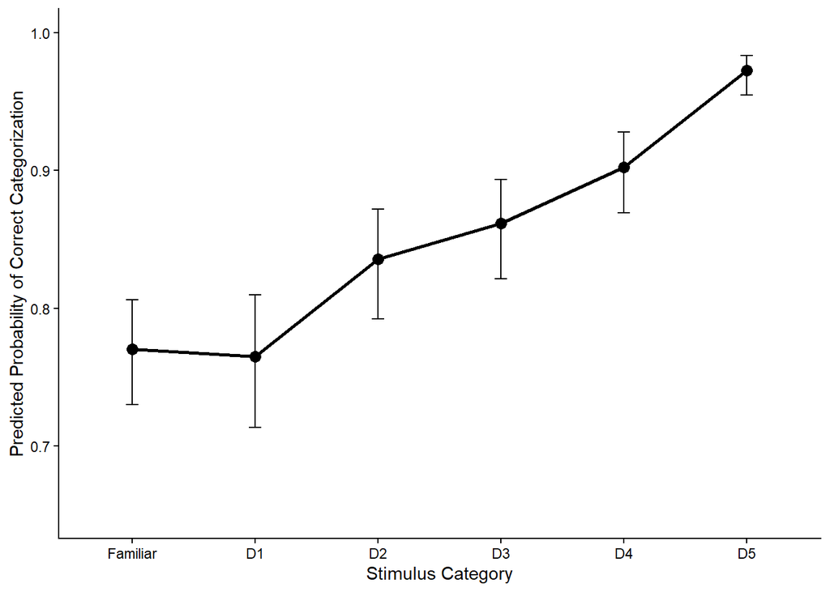

## Test phase

Use sum-to-zero contrasts so that coefficients are interpreted as deviations from the grand mean rather than comparisons with the reference level (D1). This is useful when no stimulus type serves as a theoretically meaningful baseline condition.

```
## Generalized linear mixed model fit by maximum likelihood (Laplace
##   Approximation) [glmerMod]
##  Family: binomial  ( logit )
## Formula: rt_resp ~ stimtype * test_quality + (1 | workerId) + (1 | stim)
##    Data: tdlmm
##
##       AIC       BIC    logLik -2*log(L)  df.resid
##    5922.0    5999.8   -2949.0    5898.0      4796
##
## Scaled residuals:
##     Min      1Q  Median      3Q     Max
## -4.6061 -0.9081  0.4628  0.7490  2.4335
##
## Random effects:
##  Groups   Name        Variance Std.Dev.
##  stim     (Intercept) 0.1335   0.3654
##  workerId (Intercept) 0.5036   0.7096
## Number of obs: 4808, groups:  stim, 100; workerId, 50
##
## Fixed effects:
##                           Estimate Std. Error z value Pr(>|z|)
## (Intercept)              0.4899296  0.1117507   4.384 1.16e-05 ***
## stimtype1               -0.6595464  0.0963230  -6.847 7.53e-12 ***
## stimtype2               -0.1643313  0.0962202  -1.708   0.0877 .
## stimtype3                0.0009506  0.0969090   0.010   0.9922
## stimtype4                0.0271981  0.0966222   0.281   0.7783
## test_quality1           -0.0983729  0.0486385  -2.023   0.0431 *
## stimtype1:test_quality1 -0.0059732  0.0961362  -0.062   0.9505
## stimtype2:test_quality1  0.0922221  0.0962046   0.959   0.3378
## stimtype3:test_quality1 -0.2085013  0.0969325  -2.151   0.0315 *
## stimtype4:test_quality1  0.1668039  0.0966289   1.726   0.0843 .
## ---
## Signif. codes:  0 '***' 0.001 '**' 0.01 '*' 0.05 '.' 0.1 ' ' 1
##
## Correlation of Fixed Effects:
##             (Intr) stmty1 stmty2 stmty3 stmty4 tst_q1 st1:_1 st2:_1 st3:_1
## stimtype1   -0.010
## stimtype2   -0.007 -0.239
## stimtype3   -0.002 -0.243 -0.244
## stimtype4   -0.003 -0.242 -0.243 -0.246
## test_qulty1 -0.005  0.009  0.003 -0.006  0.008
## stmtyp1:t_1  0.003  0.002 -0.003  0.001 -0.006 -0.015
## stmtyp2:t_1  0.002 -0.004 -0.006  0.004 -0.003 -0.015 -0.241
## stmtyp3:t_1 -0.004  0.003  0.004 -0.019  0.001 -0.004 -0.244 -0.244
## stmtyp4:t_1  0.004 -0.007 -0.003  0.001  0.003 -0.009 -0.242 -0.243 -0.246
```

```
## $emmeans
## stimtype = D1:
##  test_quality  emmean    SE  df asymp.LCL asymp.UCL
##  fam          -0.2740 0.182 Inf   -0.6308    0.0829
##  new          -0.0653 0.181 Inf   -0.4207    0.2902
##
## stimtype = D2:
##  test_quality  emmean    SE  df asymp.LCL asymp.UCL
##  fam           0.3194 0.182 Inf   -0.0366    0.6754
##  new           0.3317 0.182 Inf   -0.0252    0.6887
##
## stimtype = D3:
##  test_quality  emmean    SE  df asymp.LCL asymp.UCL
##  fam           0.1840 0.182 Inf   -0.1722    0.5402
##  new           0.7978 0.185 Inf    0.4358    1.1597
##
## stimtype = D4:
##  test_quality  emmean    SE  df asymp.LCL asymp.UCL
##  fam           0.5856 0.183 Inf    0.2266    0.9445
##  new           0.4487 0.182 Inf    0.0916    0.8058
##
## stimtype = D5:
##  test_quality  emmean    SE  df asymp.LCL asymp.UCL
##  fam           1.1427 0.187 Inf    0.7759    1.5095
##  new           1.4286 0.192 Inf    1.0526    1.8045
##
## Results are given on the logit (not the response) scale.
## Confidence level used: 0.95
##
## $contrasts
## stimtype = D1:
##  contrast  estimate    SE  df z.ratio p.value
##  fam - new  -0.2087 0.214 Inf  -0.975  0.3298
##
## stimtype = D2:
##  contrast  estimate    SE  df z.ratio p.value
##  fam - new  -0.0123 0.214 Inf  -0.057  0.9542
##
## stimtype = D3:
##  contrast  estimate    SE  df z.ratio p.value
##  fam - new  -0.6137 0.217 Inf  -2.834  0.0046
##
## stimtype = D4:
##  contrast  estimate    SE  df z.ratio p.value
##  fam - new   0.1369 0.216 Inf   0.635  0.5255
##
## stimtype = D5:
##  contrast  estimate    SE  df z.ratio p.value
##  fam - new  -0.2858 0.227 Inf  -1.261  0.2072
##
## Results are given on the log odds ratio (not the response) scale.
```

### Test phase - Figure

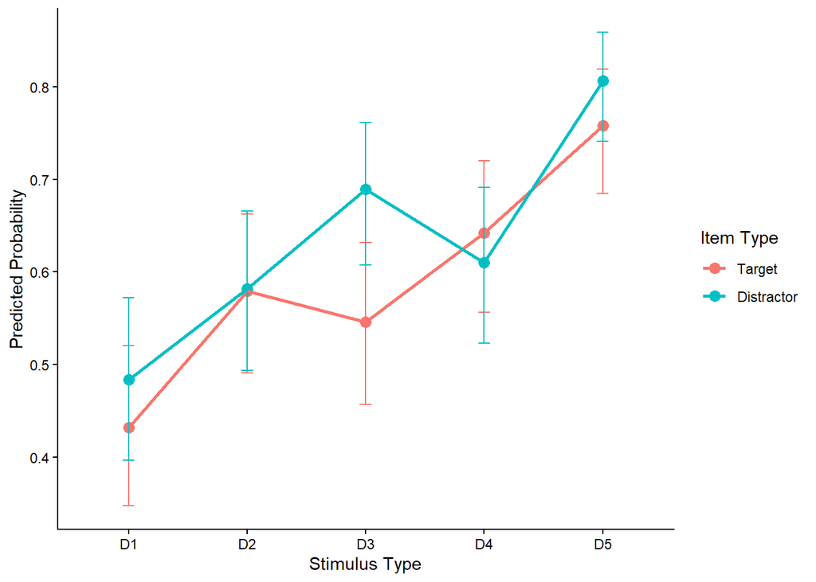

## Study - Test responding

Correct categorization of novels during study does not affect recognition responses.

```
## # A tibble: 2,500 × 9
##    workerId stim     stimtype.x study_corr study_response study_sequence rt_corr
##       <dbl> <chr>    <fct>           <dbl> <chr>                   <dbl>   <dbl>
##  1      357 p2d3_2.… D3                  1 right                      25       1
##  2      357 p3d3_1.… D3                  1 right                       3       0
##  3      357 p1d3_2.… D3                  1 right                      49       1
##  4      357 p1d1_2.… D1                  1 right                      40       0
##  5      357 p4d3_2.… D3                  1 right                      22       0
##  6      357 p5d3_1.… D3                  0 left                       42      NA
##  7      357 p4d3_1.… D3                  1 right                      23       1
##  8      357 p2d4_2.… D4                  1 right                      28       1
##  9      357 p5d3_2.… D3                  1 right                      71       0
## 10      357 p8d4_2.… D5                  0 None                       14       0
## # ℹ 2,490 more rows
## # ℹ 2 more variables: rt_resp <dbl>, count_test_sequence <dbl>
```

```
## Generalized linear mixed model fit by maximum likelihood (Laplace
##   Approximation) [glmerMod]
##  Family: binomial  ( logit )
## Formula: rt_corr ~ study_corr * stimtype + (1 | workerId) + (1 | stim)
##    Data: target_dat
##
##       AIC       BIC    logLik -2*log(L)  df.resid
##    3071.9    3141.4   -1524.0    3047.9      2395
##
## Scaled residuals:
##     Min      1Q  Median      3Q     Max
## -2.1154 -0.7720 -0.5009  0.9270  3.5380
##
## Random effects:
##  Groups   Name        Variance Std.Dev.
##  workerId (Intercept) 0.3625   0.6021
##  stim     (Intercept) 0.1193   0.3454
## Number of obs: 2407, groups:  workerId, 50; stim, 50
##
## Fixed effects:
##                      Estimate Std. Error z value Pr(>|z|)
## (Intercept)          -0.17965    0.18531  -0.969  0.33233
## study_corr           -0.23389    0.16614  -1.408  0.15919
## stimtype1             0.72764    0.23987   3.033  0.00242 **
## stimtype2            -0.27756    0.25885  -1.072  0.28359
## stimtype3             0.37737    0.26844   1.406  0.15979
## stimtype4             0.02222    0.29786   0.075  0.94054
## study_corr:stimtype1 -0.13153    0.24277  -0.542  0.58796
## study_corr:stimtype2  0.41442    0.26016   1.593  0.11117
## study_corr:stimtype3 -0.20620    0.26969  -0.765  0.44452
## study_corr:stimtype4 -0.22373    0.29833  -0.750  0.45328
## ---
## Signif. codes:  0 '***' 0.001 '**' 0.01 '*' 0.05 '.' 0.1 ' ' 1
##
## Correlation of Fixed Effects:
##             (Intr) stdy_c stmty1 stmty2 stmty3 stmty4 std_:1 std_:2 std_:3
## study_corr  -0.811
## stimtype1   -0.348  0.388
## stimtype2   -0.243  0.270  0.022
## stimtype3   -0.194  0.215 -0.014 -0.059
## stimtype4   -0.074  0.083 -0.087 -0.123 -0.143
## stdy_crr:s1  0.337 -0.370 -0.831 -0.058 -0.020  0.052
## stdy_crr:s2  0.240 -0.268 -0.058 -0.861  0.027  0.093  0.016
## stdy_crr:s3  0.190 -0.213 -0.018  0.027 -0.871  0.114 -0.022 -0.061
## stdy_crr:s4  0.076 -0.087  0.054  0.093  0.115 -0.895 -0.088 -0.122 -0.143
```